# EEMB 146 Final Report: Down to the Root: Digging into Soil pH and Moisture in Managed Grasslands

Linh Dang

## Abstract

This project investigates how land management practices influence soil pH and whether soil moisture serves as a predictor of pH in a temperate grassland ecosystem. The dataset includes measurements of soil pH and soil moisture under three treatments: Enclosure, Grazing, and Mowing. We conducted a one-way ANOVA to assess differences in soil pH across treatments and used linear regression to test whether log-transformed soil moisture predicts pH. The ANOVA revealed no significant differences in soil pH among treatments. However, the regression analysis showed a significant negative relationship between soil moisture and pH. These findings suggest that while treatment type may not directly affect soil pH, changes in soil moisture associated with land use can influence soil acidity.

## Introduction

Grasslands are critical ecosystems that provide habitat, support biodiversity, and regulate essential ecological processes such as nutrient cycling and soil health (Fitter et al., 2005; Smith et al., 2008). However, human land-use practices like grazing and mowing can significantly alter soil conditions, potentially affecting long-term ecosystem function and sustainability (Zheng et al., 2023; Wang et al., 2019). Understanding how land management influences soil chemistry—particularly soil pH—is important because pH regulates nutrient availability, shapes microbial communities, and influences plant productivity.

My primary research question is: Does land-use treatment influence soil pH? I used a one-way ANOVA with pH as the response variable and treatment as the predictor.

Null hypothesis (H₀): Mean pH is equal across all three treatments (Enclosure, Grazing, Mowing).

Alternative hypothesis (H₁): At least one treatment group has a different mean pH.

My second question asks: Does soil moisture predict soil pH? I used a linear regression with pH as the response and log-transformed soil moisture (SM_log) as the predictor.

Null hypothesis (H₀): There is no relationship between SM_log and pH (slope = 0).

Alternative hypothesis (H₁): There is a relationship between SM_log and pH (slope ≠ 0).

These questions matter because soil pH is a key indicator of soil health. If management practices significantly alter pH, they may affect plant communities, microbial processes, and overall ecosystem function. By analyzing how pH responds to treatment and moisture, we can better inform sustainable grassland management.

## Exploratory Data Analysis

To explore the data, I first examined the distribution of the response variable, soil pH. As shown in Figure 1, the histogram suggests that pH is approximately normally distributed with no extreme outliers. In Figure 2, a scatterplot of pH versus log-transformed soil moisture reveals a negative trend, indicating that soil pH tends to decrease as soil moisture increases. Lastly, Figure 3 displays boxplots of pH across the three land-use treatments (Enclosure, Grazing, Mowing), showing some variation but no strong differences in central tendency among the groups.

These exploratory plots helped guide the selection of appropriate statistical tests and supported the assumptions required for valid inference.

# 1. Distribution of of pH (response variable)

```
## [1] 18  4
```

```
##
##  Shapiro-Wilk normality test
##
## data:  clean_data$pH
## W = 0.97452, p-value = 0.6869
```

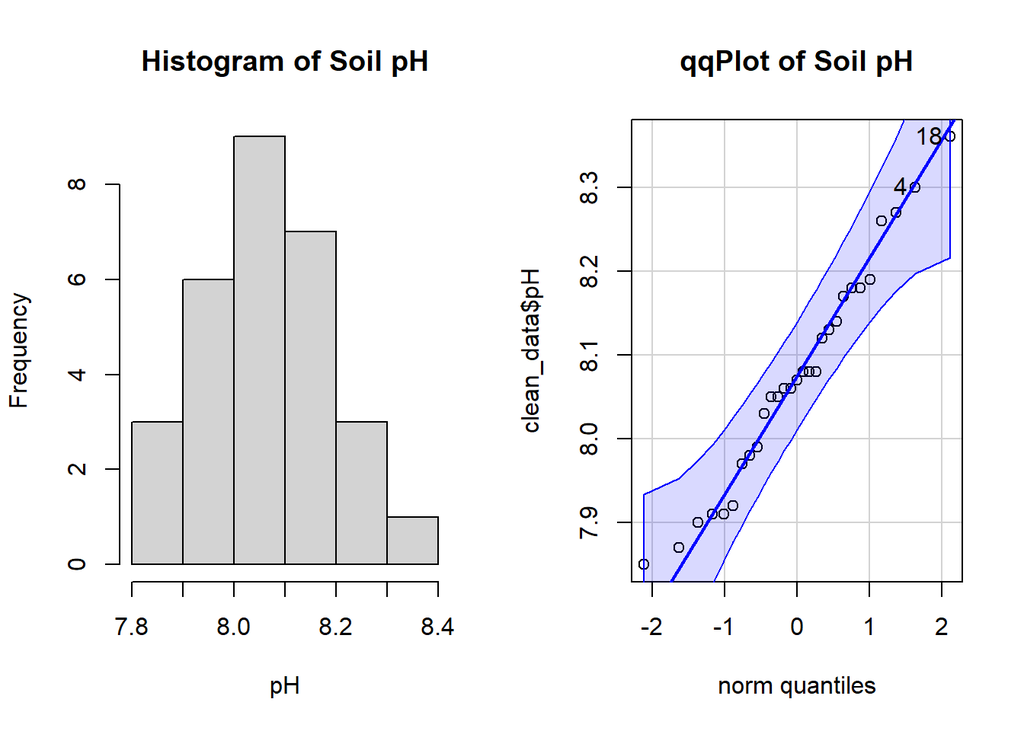

Fig. 1: Histogram and Q-Q plot of soil pH. The histogram shows a fairly symmetric distribution centered around pH 8.0, with most values between 7.9 and 8.2. The Q-Q plot shows points closely following the normal line, indicating approximate normality. The Shapiro-Wilk test supports this with a high p-value (p = 0.6869), suggesting that the data do not significantly deviate from a normal distribution. Therefore, using parametric tests like ANOVA or linear regression with pH is appropriate.

Summary:

We examined the distribution of soil pH using a histogram, Q-Q plot, and Shapiro-Wilk test. The histogram shows a roughly symmetric distribution centered around pH 8.0. The Q-Q plot indicates the data closely follow a normal distribution. The Shapiro-Wilk test gave W = 0.9745 with p = 0.6869, which is greater than 0.05. This means the distribution of pH is not significantly different from normal. There are no major outliers visible in the histogram or Q-Q plot.

# 2. Relationship between SM_log and pH (numeric ~ numeric)

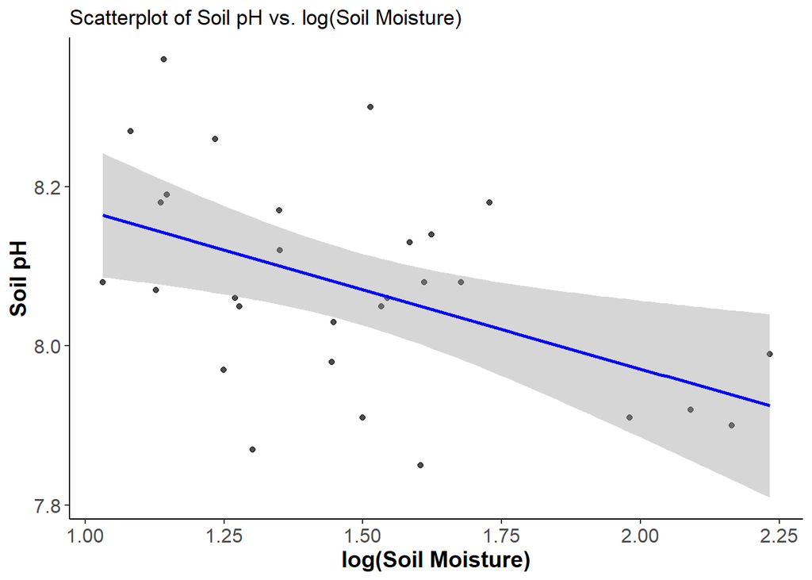

Fig. 2: Scatterplot of soil pH (response variable) against log-transformed soil moisture (log(SM)). Each point represents one soil sample. The plot shows a moderate negative trend — as log(SM) increases, soil pH tends to decrease. No extreme outliers are visible.

Summary: We explored the relationship between soil pH (response) and log-transformed soil moisture (log(SM)) using a scatterplot with a fitted regression line. The plot shows a moderate negative trend: as log(SM) increases, soil pH generally decreases. This pattern is consistent with our hypothesis that soil moisture may influence soil pH. No major outliers are visible in the scatterplot.

# 3. Relationship between pH and treat (numeric ~ categorical)

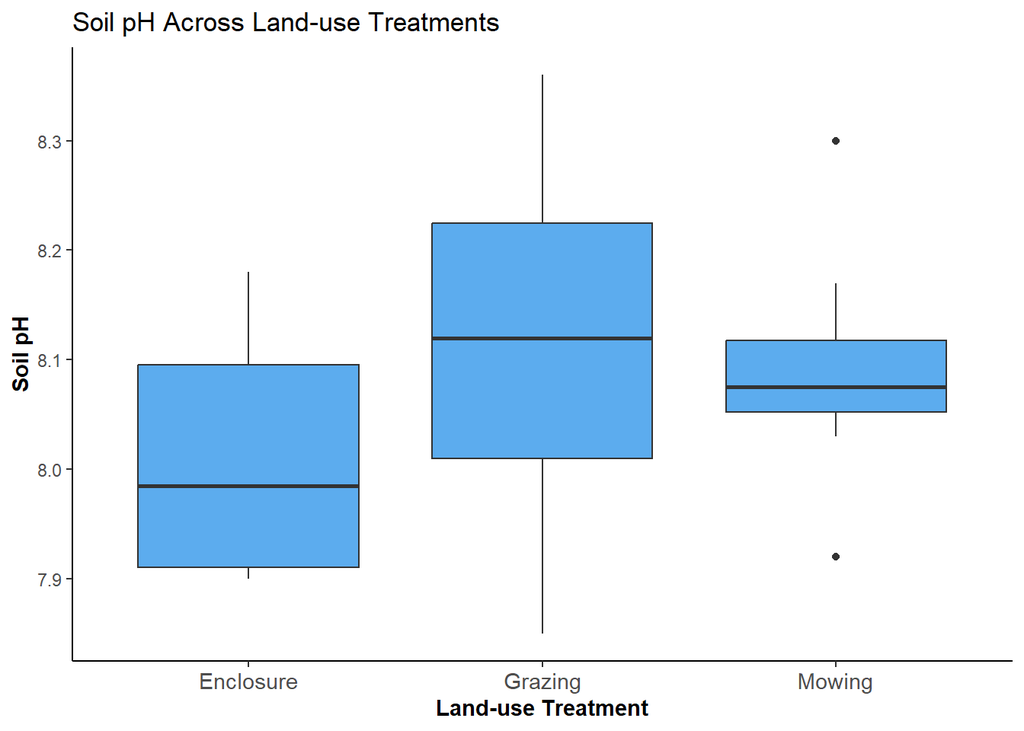

Fig. 3: Boxplot of soil pH across land-use treatments (Enclosure, Grazing, Mowing). Each box shows the median, interquartile range (IQR), and potential outliers.Grazing sites show slightly higher pH variability, while Enclosure and Mowing appear more concentrated.A few mild outliers are visible, especially in the Mowing group.

Summary: We examined how soil pH varies across three land-use treatments using a boxplot. The Enclosure and Mowing groups show narrower interquartile ranges compared to Grazing. Grazing appears to have a slightly higher median and more spread. A few mild outliers are visible, particularly in the Mowing group. This plot helps visualize variation in the response variable (pH) across treatments before formal testing.

## Statistical Methods

#### Anova: : Comparing the Mean Soil pH Across Treatments

To determine whether soil pH varies across treatments (Enclosure, Grazing, and Mowing), I used a one-way ANOVA.

Hypotheses: Null hypothesis ($H_0$): The mean soil pH is the same across all treatments.

Alternative hypothesis ($H_A$): At least one treatment has a different mean soil pH.

Checking Assumptions Normality of residuals: The Shapiro-Wilk test showed that residuals were approximately normal ($W = 0.983$, $p-value = 0.898$), so the normality assumption is met. The Q-Q plot and histogram (Figure 5) also visually confirm normality.

Equal variances: Levene’s Test showed no significant difference in variances ($F-value = 2.14$, $p-value = 0.138$), so the assumption of homogeneity of variance is met.

The ANOVA result was not statistically significant: $F-value = 1.343$, $p-value = 0.279$, $\alpha = 0.05$. Therefore, I failed to reject the null hypothesis that mean soil pH is the same across treatments.

```
## [1] 12 18
```

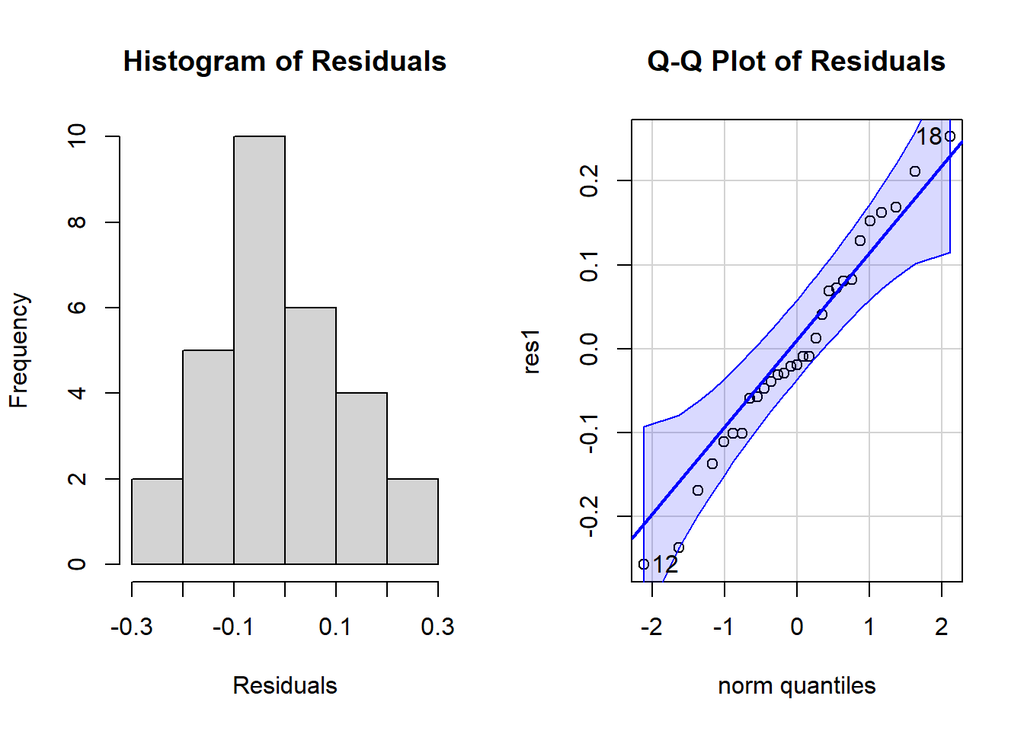

Fig. 5: Diagnostic plots used to assess the assumptions of one-way ANOVA on soil pH. The Q-Q plot shows that the residuals fall approximately along the reference line, indicating that the residuals are normally distributed (Shapiro-Wilk test, W = 0.983, p = 0.898). The histogram of residuals shows a roughly symmetric, bell-shaped distribution. Together, these plots support the assumption of normality for ANOVA. These diagnostics confirm that ANOVA assumptions are reasonably met.

#### Linear model: Predicting soil pH from log-transformed soil moisture

I tested whether log-transformed soil moisture predicts soil pH using a simple linear regression.

Null hypothesis ($H_0$): There is no linear relationship between log-transformed soil moisture and soil pH ($\beta_1 = 0$). Alternative hypothesis ($H_A$): There is a linear relationship between log-transformed soil moisture and soil pH ($\beta_1 \neq 0$).

Linear regression is appropriate for testing relationships between two continuous variables. I checked model assumptions using diagnostic plots and a Shapiro-Wilk test for normality of residuals. The residuals appeared approximately normal (Shapiro-Wilk W = 0.989, p = 0.986), and the plots did not indicate any serious violations of assumptions.

The regression model was statistically significant ($F = 8.37$, $p = 0.007$, $\alpha = 0.05$), explaining about 23.7% of the variation in soil pH ($R^2 = 0.237$). The slope ($\beta_1 = -0.199$) indicates that as log-transformed soil moisture increases by one unit, soil pH decreases by approximately 0.199 units. The intercept ($\beta_0 = 8.370$) represents the estimated pH when log(SM) is zero.

## Results

#### Does pH differ among treatments?

I found no significant difference in mean soil pH among treatments (one-way ANOVA; $\alpha = 0.05$, $F-value = 1.343$, $p-value = 0.279$). The assumptions of ANOVA were met: the residuals were normally distributed (Shapiro-Wilk test, $W = 0.983$, $p = 0.898$) and variances were homogeneous (Levene’s Test, $F = 2.141$, $p = 0.138$).

Therefore, I failed to reject the null hypothesis that the mean soil pH is equal across the Enclosure, Grazing, and Mowing treatments. See Figure 7 for a boxplot illustrating soil pH across treatments.

**NOTE: i literally did all my analyses in the appendix and then copied and pasted my favorite plots up here so they show up in the main body!**

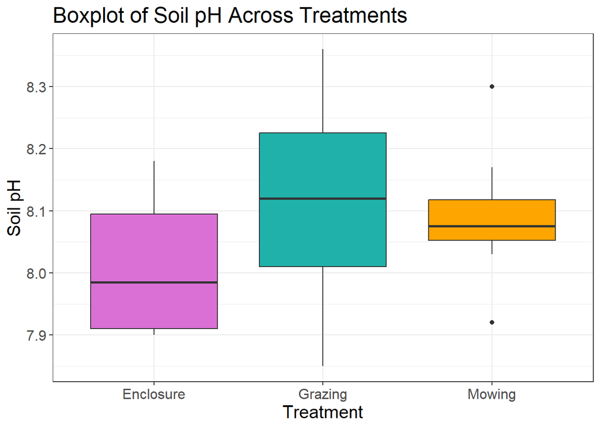

Fig. 7: Boxplot showing soil pH across Enclosure, Grazing, and Mowing treatments. No significant difference was detected (ANOVA, p = 0.279), suggesting treatment type does not affect pH.

#### Does pH change with soil moisture?

I found a statistically significant negative relationship between soil pH and log-transformed soil moisture (linear regression; $\alpha = 0.05$, $F-value = 8.37$, $p-value = 0.007$, $R^2$ = 0.237). The slope ($b_1$) was -0.199, meaning that for each one-unit increase in log(soil moisture), soil pH decreased by approximately 0.199 units. The intercept ($b_0$) was 8.370.

The assumptions of linear regression were met: residuals appeared approximately normally distributed (Shapiro-Wilk test, $W = 0.989$, $p = 0.986$), and diagnostic plots did not show major deviations.

## Discussion

In this study, I explored how soil pH varies with different land treatments and how it relates to soil moisture levels. My first analysis (Test 1) tested whether mean pH levels differ among the Enclosure, Grazing, and Mowing treatments. The results of the one-way ANOVA showed no significant differences in pH between treatments. This suggests that treatment type, under the conditions observed, may not be a strong driver of soil pH variation.

In contrast, my second analysis (Test 2) revealed a statistically significant negative relationship between soil pH and log-transformed soil moisture. Specifically, as soil moisture increases, soil pH tends to decrease, indicating that wetter soils are more acidic. This supports the hypothesis that soil moisture influences pH, possibly through changes in microbial activity or leaching of basic cations.

Together, these results suggest that soil moisture may play a more important role in shaping soil pH than treatment type in this dataset. Biologically, this implies that hydrological conditions, rather than land use treatment alone, may be a key factor regulating acidity in this ecosystem.

There are, however, limitations to consider. The sample size is relatively small, which limits the statistical power of the ANOVA and may make it harder to detect treatment effects. Additionally, other variables that could influence pH, such as soil texture, organic matter, or nutrient levels, were not included in this analysis. It is also possible that treatment effects on pH require more time to become detectable, or vary spatially beyond what was captured here.

If given more time or a larger dataset, I would consider including block as a random effect in a mixed model to control for spatial variation. I would also examine other soil properties and explore potential interactions between treatment and moisture.

The final take-away is that soil moisture appears to be an important factor influencing soil pH, while land treatment effects were not evident in this dataset. Understanding this relationship can inform land management decisions aimed at maintaining soil health and ecosystem function.

## References

Journal articles

Fitter, A. H., et al. “Biodiversity and ecosystem function in soil.” Functional Ecology 19.3 (2005): 369–377. https://doi.org/10.1111/j.0269-8463.2005.00969.x

Zheng, Jiahua, et al. “Effects of fencing on near-term ecosystem multifunctionality in a typical steppe in Inner Mongolia.” Agriculture, Ecosystems & Environment 342 (2023): 108238. https://doi.org/10.1016/j.agee.2022.108238

Smith, Pete, et al. “Greenhouse gas mitigation in agriculture.” Philosophical Transactions of the Royal Society B: Biological Sciences 363.1492 (2008): 789–813. https://doi.org/10.1098/rstb.2007.2184

R Packages Used:

Fox J, Weisberg S (2019). *An R Companion to Applied Regression*, Third edition. Sage, Thousand Oaks CA. https://www.john-fox.ca/Companion/.

Hothorn T, Bretz F, Westfall P (2008). “Simultaneous Inference in General Parametric Models.” *Biometrical Journal*, *50*(3), 346-363.

William Revelle (2025). *psych: Procedures for Psychological, Psychometric, and Personality Research*. Northwestern University, Evanston, Illinois. R package version 2.5.6, https://CRAN.R-project.org/package=psych.

H. Wickham. ggplot2: Elegant Graphics for Data Analysis. Springer-Verlag New York, 2016.

Wickham H, Averick M, Bryan J, Chang W, McGowan LD, François R, Grolemund G, Hayes A, Henry L, Hester J, Kuhn M, Pedersen TL, Miller E, Bache SM, Müller K, Ooms J, Robinson D, Seidel DP, Spinu V, Takahashi K, Vaughan D, Wilke C, Woo K, Yutani H (2019). “Welcome to the tidyverse.” *Journal of Open Source Software*, *4*(43), 1686. doi:10.21105/joss.01686 https://doi.org/10.21105/joss.01686.

Wickham H, François R, Henry L, Müller K, Vaughan D (2023). *dplyr: A Grammar of Data Manipulation*. doi:10.32614/CRAN.package.dplyr https://doi.org/10.32614/CRAN.package.dplyr, R package version 1.1.4, https://CRAN.R-project.org/package=dplyr.

Wickham H, Hester J, Bryan J (2024). *readr: Read Rectangular Text Data*. doi:10.32614/CRAN.package.readr https://doi.org/10.32614/CRAN.package.readr, R package version 2.1.5, https://CRAN.R-project.org/package=readr.

Wickham H, Vaughan D, Girlich M (2024). *tidyr: Tidy Messy Data*. doi:10.32614/CRAN.package.tidyr https://doi.org/10.32614/CRAN.package.tidyr, R package version 1.3.1, https://CRAN.R-project.org/package=tidyr.

Wilke C (2024). *cowplot: Streamlined Plot Theme and Plot Annotations for ‘ggplot2’*. doi:10.32614/CRAN.package.cowplot https://doi.org/10.32614/CRAN.package.cowplot, R package version 1.1.3, https://CRAN.R-project.org/package=cowplot.

Dataset Source:

Wang, D., Ren, H., Jin, Y., & Ma, M. (2019). Land use alters relationships of grassland productivity with plant and arthropod diversity in Inner Mongolian grassland. https://doi.org/10.5061/dryad.2fqz612k9

## Appendix

### All code goes here!!! Do NOT forget to annotate do not include long printouts of entire datasets - the code is worth a lot of your grade!

### Section 1: Exploratory data analysis

```r
# ==============================
# Part 1: Data Cleaning
# ==============================

#filter observations
clean_data <- dataset_38 %>%
  dplyr::select(treat,SM,pH, block) %>%   # keep only relevant columns
  tidyr::drop_na() # remove all rows with NAs

#change block as factor
clean_data$block <- as.factor(clean_data$block)

#general data checking
head(clean_data)
```

```
##       treat     SM   pH block
## 1 Enclosure 8.7054 7.90     3
## 2    Mowing 3.8541 8.17     1
## 3    Mowing 4.2506 8.03     2
## 4    Mowing 4.5444 8.30     1
## 5   Grazing 3.4866 7.97     2
## 6   Grazing 2.9487 8.27     1
```

```r
summary(clean_data)
```

```
##     treat                 SM              pH        block
##  Length:29          Min.   :2.804   Min.   :7.850   1:10
##  Class :character   1st Qu.:3.487   1st Qu.:7.980   2: 9
##  Mode  :character   Median :4.251   Median :8.070   3:10
##                     Mean   :4.648   Mean   :8.074
##                     3rd Qu.:5.007   3rd Qu.:8.170
##                     Max.   :9.325   Max.   :8.360
```

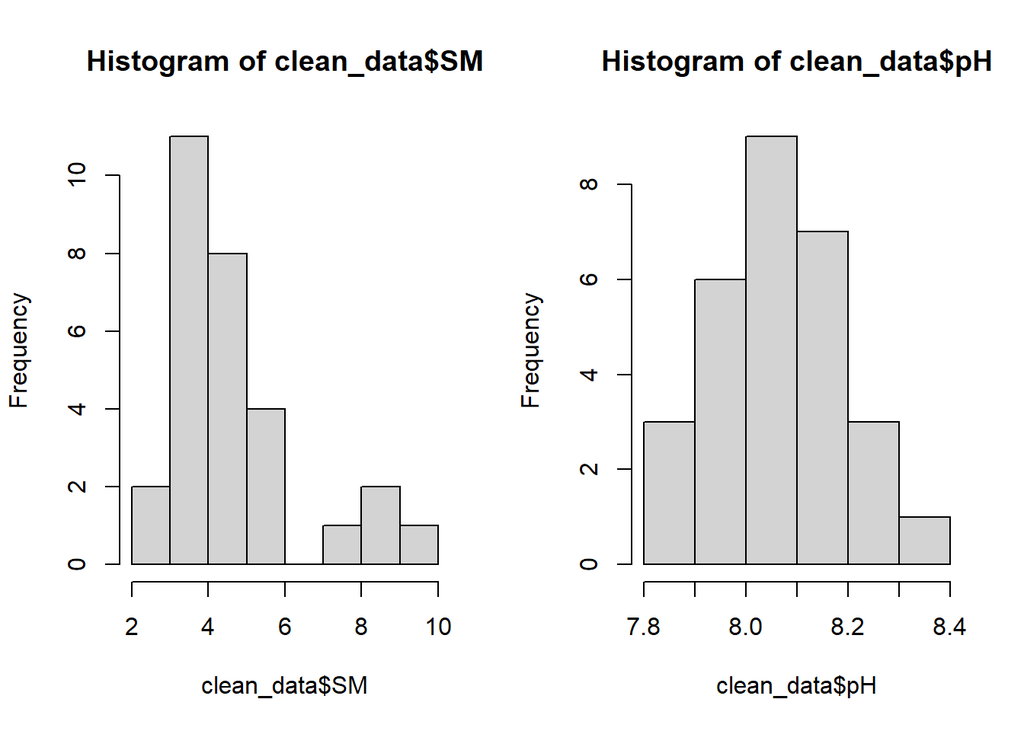

```r
# ==============================
# Part 2: EDA - Distribution Checks
# ==============================

#check numeric vars for distributions and normality
## histograms
par(mfrow=c(1,2))
hist(clean_data$SM)
hist(clean_data$pH)
```

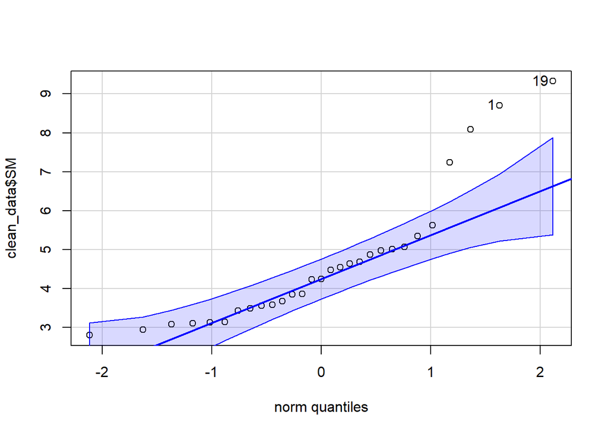

```
## [1] 19  1
```

```r
par(mfrow=c(1,1))


## qqPlots
par(mfrow=c(1,1))
qqPlot(clean_data$SM)
```

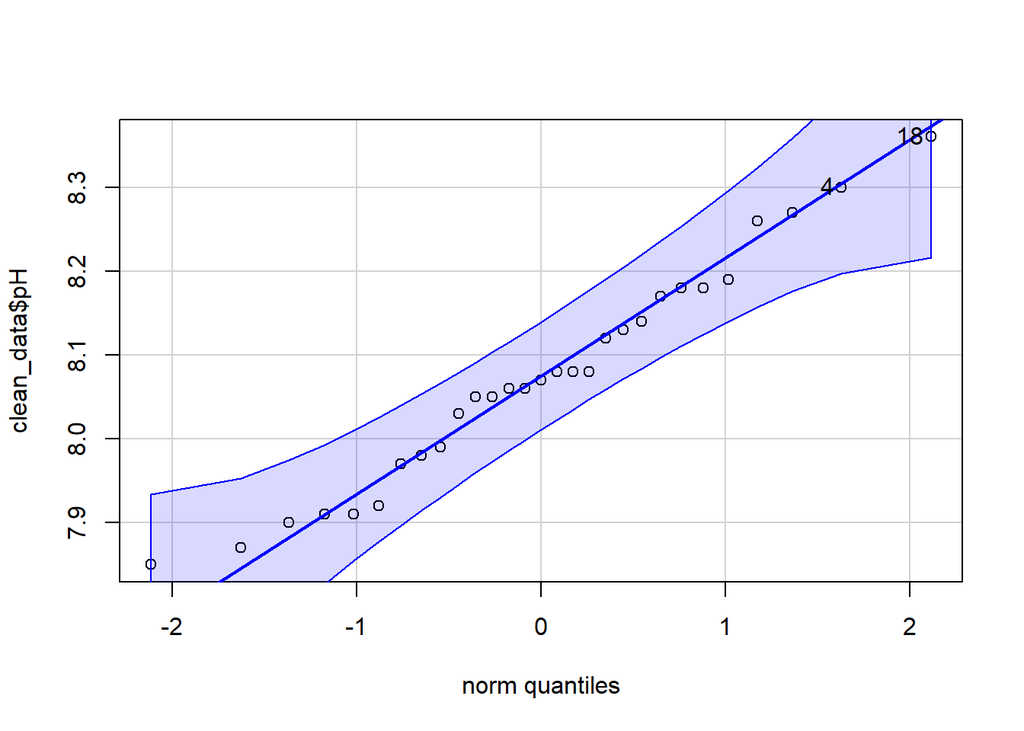

```
## [1] 18  4
```

```r
qqPlot(clean_data$pH)
```

```r
par(mfrow=c(1,1))


## shapiro tests
shapiro.test(clean_data$SM) # not
```

```
##
##  Shapiro-Wilk normality test
##
## data:  clean_data$SM
## W = 0.83038, p-value = 0.0003082
```

```r
shapiro.test(clean_data$pH) # normal
```

```
##
##  Shapiro-Wilk normality test
##
## data:  clean_data$pH
## W = 0.97452, p-value = 0.6869
```

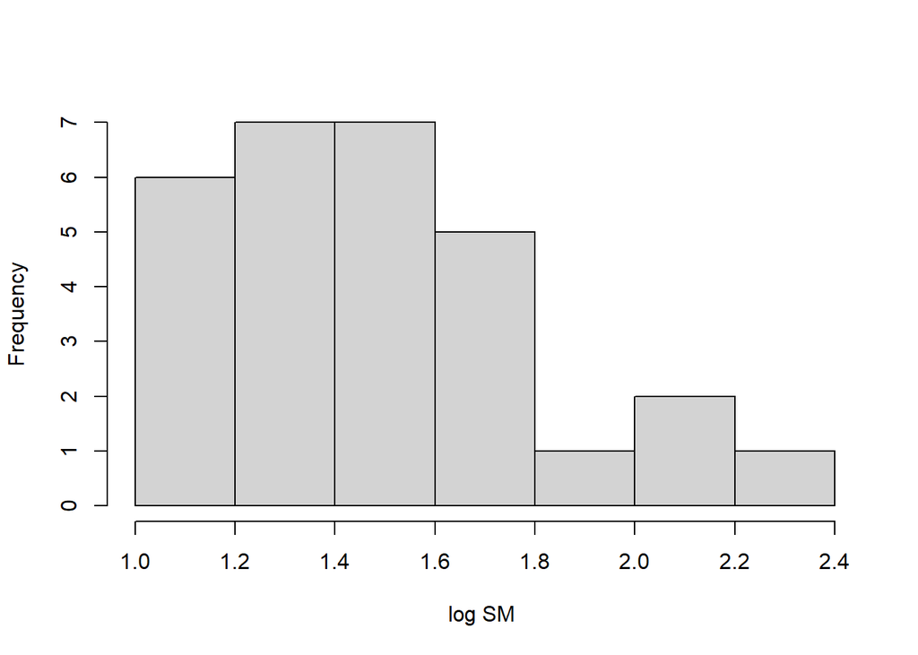

```r
## Hint: Check if there are 0s or negatives using range() before transforming
#range(clean_data$SM) #[1] 2.8045 9.3250 so no need add 1 when transforming

clean_data$SM_log <- log(clean_data$SM)

hist(clean_data$SM_log, main="", xlab="log SM ")
```

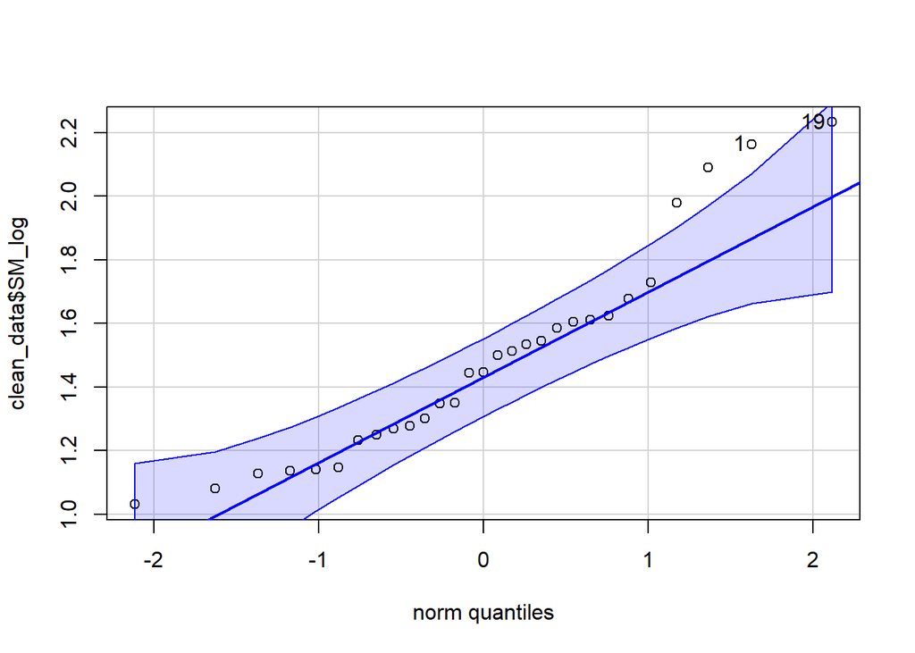

```
## [1] 19  1
```

```r
qqPlot(clean_data$SM_log)
```

```r
shapiro.test(clean_data$SM_log)
```

```
##
##  Shapiro-Wilk normality test
##
## data:  clean_data$SM_log
## W = 0.9231, p-value = 0.03655
```

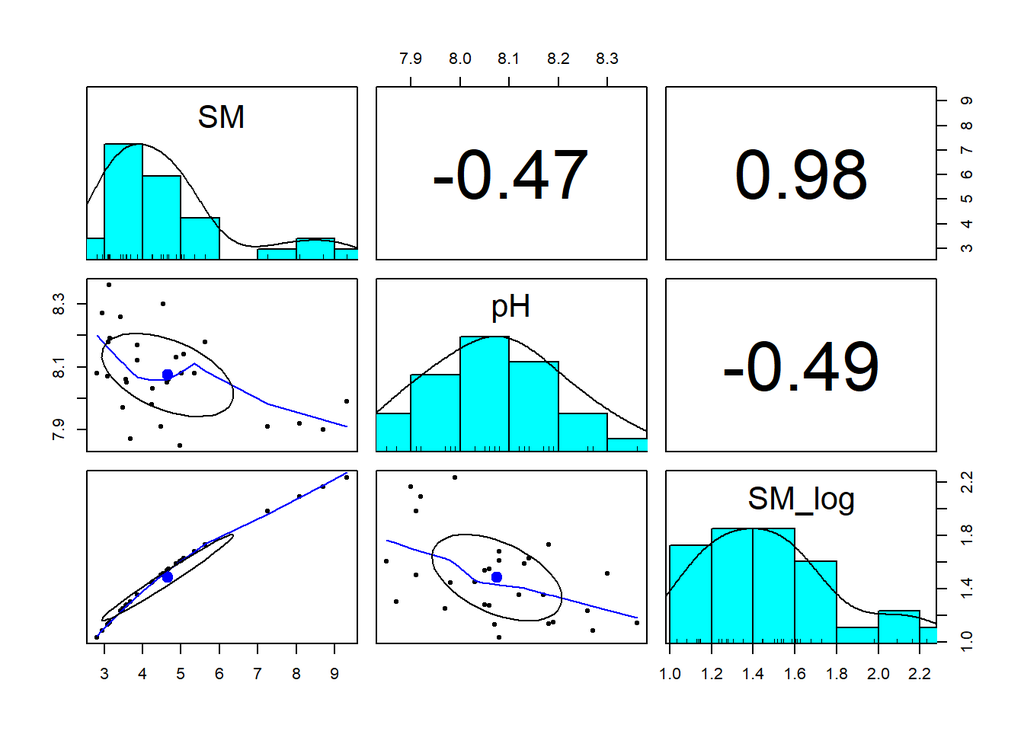

```r
#prep for pairs panels: only numeric vars
numerics <- clean_data[,c("SM", "pH", "SM_log")]
pairs.panels(numerics) #include as a fig
```

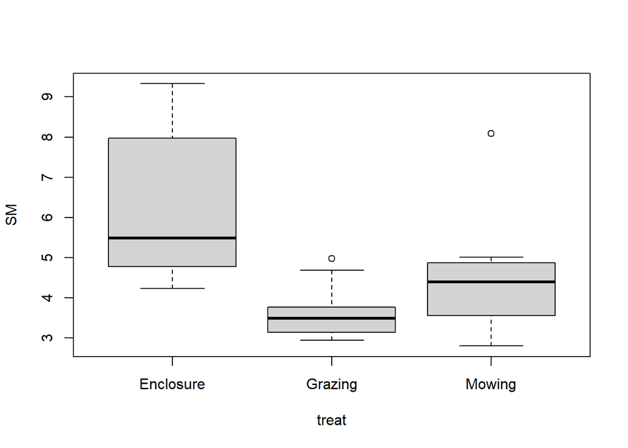

```r
# numeric ~ categorical exploration
boxplot(SM ~ treat, data=clean_data)
```

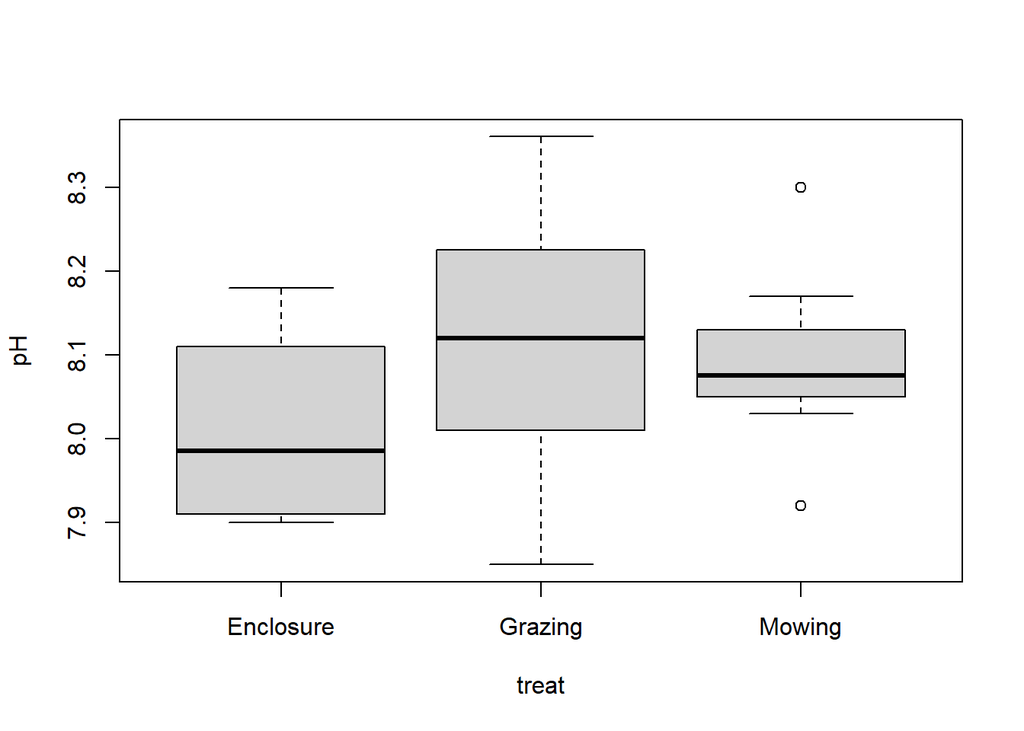

```r
boxplot(pH ~ treat, data=clean_data)
```

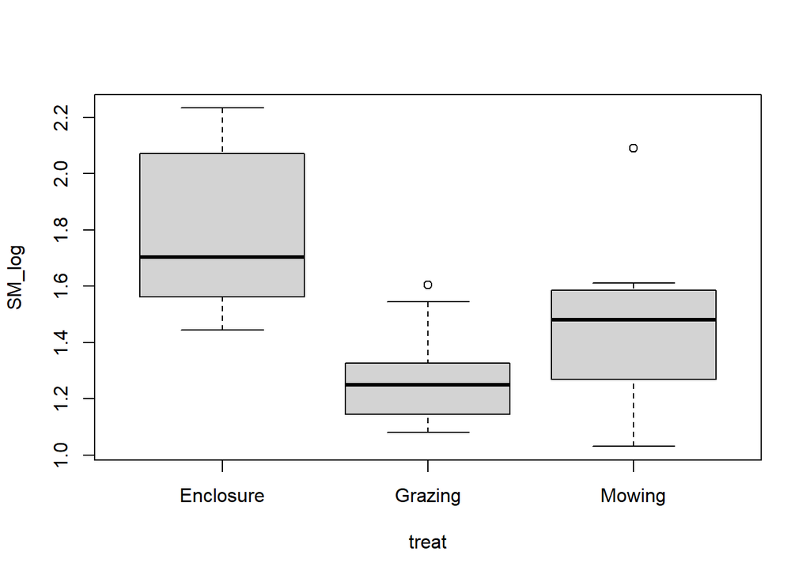

```r
boxplot(SM_log ~ treat, data=clean_data)
```

### Section 2: Statistical methods

#### ANOVA on pH

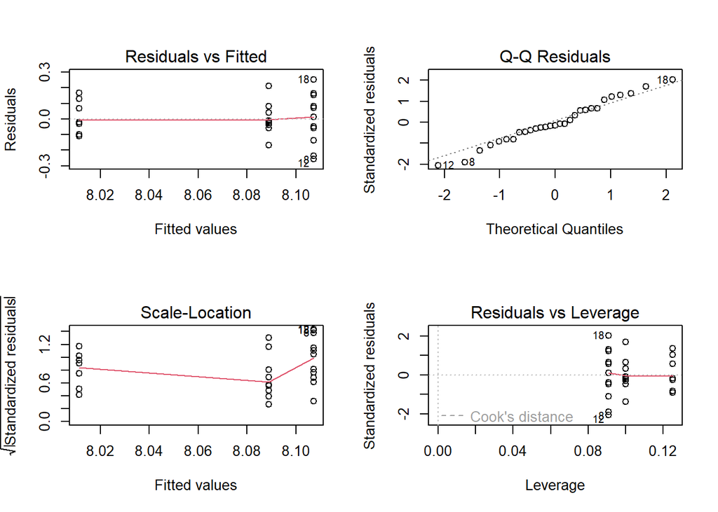

```r
# ==============================
# Part 3: ANOVA - pH ~ treat
# ==============================

# Fit linear model with pH as the response variable and treatment as the predictor
fit1 <- lm(pH ~ treat, data=clean_data)

# Diagnostic plots to check ANOVA assumptions
par(mfrow=c(2,2))
plot(fit1) # residuals, Q-Q plot, leverage
```

```r
par(mfrow=c(1,1))

# Extract residuals and assess normality
res1 <- fit1$residuals
shapiro.test(res1)
```

```
##
##  Shapiro-Wilk normality test
##
## data:  res1
## W = 0.98256, p-value = 0.8979
```

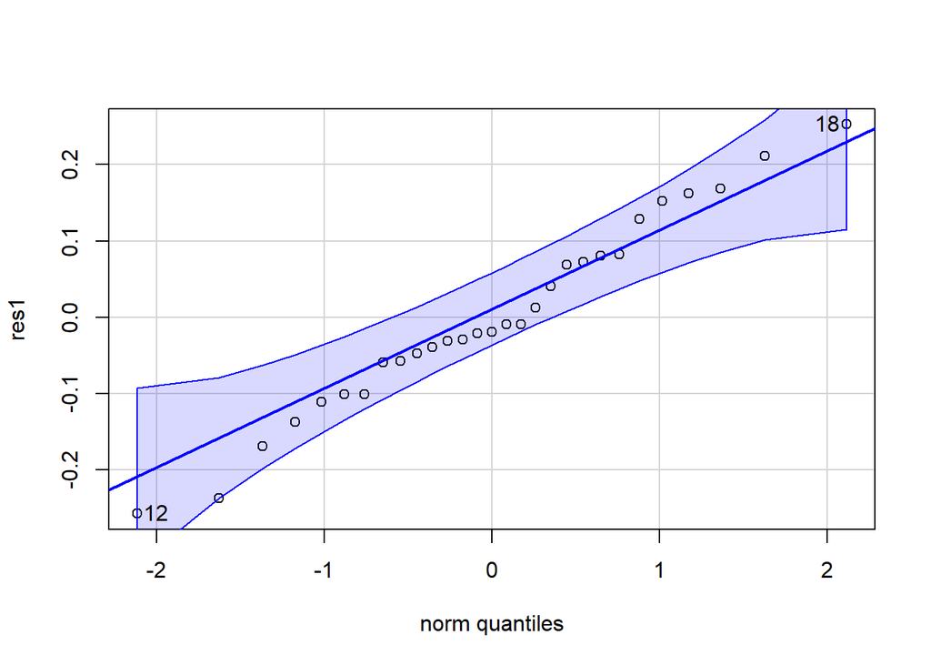

```
## [1] 12 18
```

```r
qqPlot(res1)
```

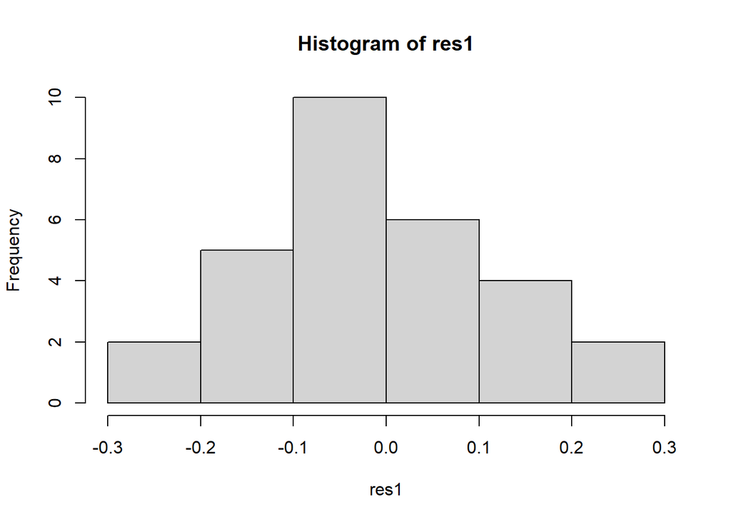

```r
hist(res1)
```

```r
# Run one-way ANOVA
anova(fit1)
```

```
## Analysis of Variance Table
##
## Response: pH
##           Df  Sum Sq  Mean Sq F value Pr(>F)
## treat      2 0.04592 0.022961  1.3427 0.2786
## Residuals 26 0.44460 0.017100
```

```r
# Check homogeneity of variances with Levene's Test
leveneTest(pH ~ treat, data=clean_data)
```

```
## Levene's Test for Homogeneity of Variance (center = median)
##       Df F value Pr(>F)
## group  2  2.1405 0.1379
##       26
```

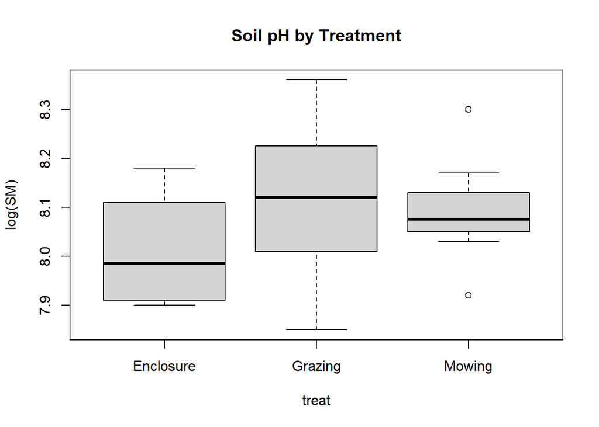

```r
boxplot(pH ~ treat, data = clean_data, main = "Soil pH by Treatment", ylab = "log(SM)")
```

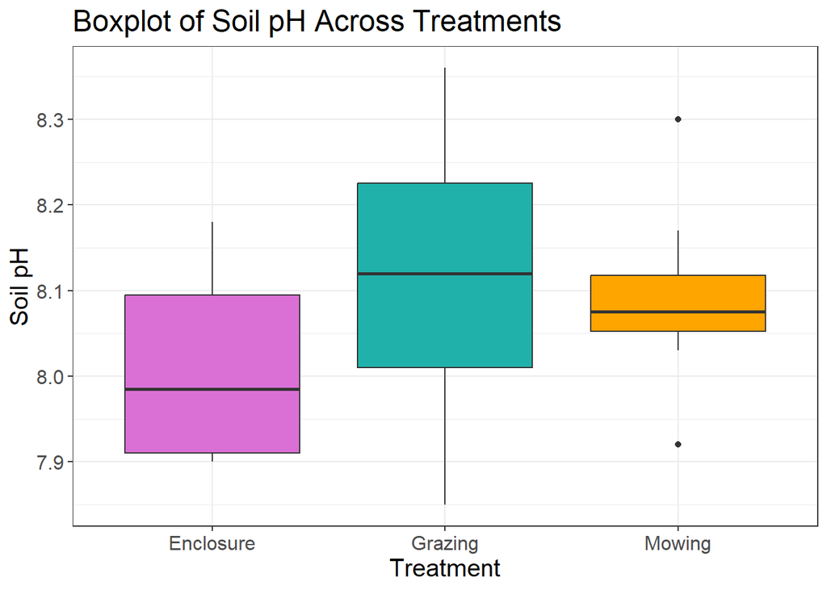

```r
# ggplot version of boxplot
ggplot(clean_data, aes(x=treat, y=pH, fill=treat, fill=treat))+ #base plot
  geom_boxplot(show.legend=F)+ #do a boxplot, but hide legend cause its just colors
  scale_fill_manual(values=c("orchid", "lightseagreen", "orange"))+ #set line colors
  ylab("Soil pH")+
  xlab("Treatment")+
  theme_bw()+ #cute theme
  theme(text = element_text(size=15))+ # Larger font
  ggtitle("Boxplot of Soil pH Across Treatments")
```

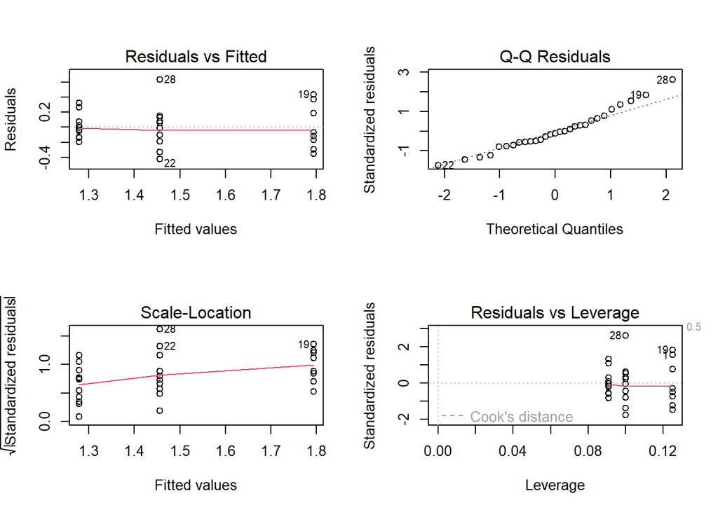

```r
# ==============================
# Part 4: ANOVA - SM_log ~ treat
# ==============================

# Fit linear model: SM as response, treat as predictor
fit2 <- lm(SM_log ~ treat, data=clean_data)

# Diagnostic plots to check ANOVA assumptions
par(mfrow=c(2,2))
plot(fit2)
```

```r
par(mfrow=c(1,1))

# Residuals normality check
res2 <- fit2$residuals
shapiro.test(res2)
```

```
##
##  Shapiro-Wilk normality test
##
## data:  res2
## W = 0.96983, p-value = 0.555
```

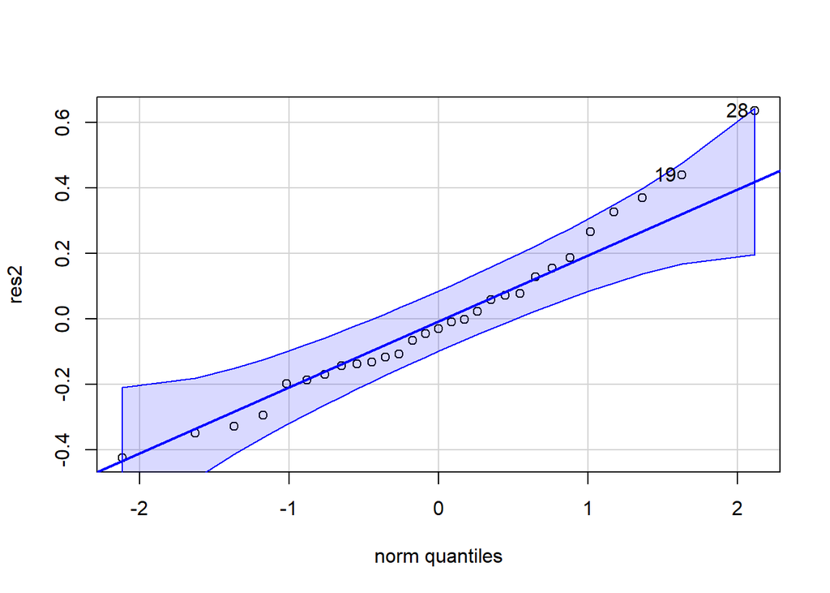

```
## [1] 28 19
```

```r
qqPlot(res2)
```

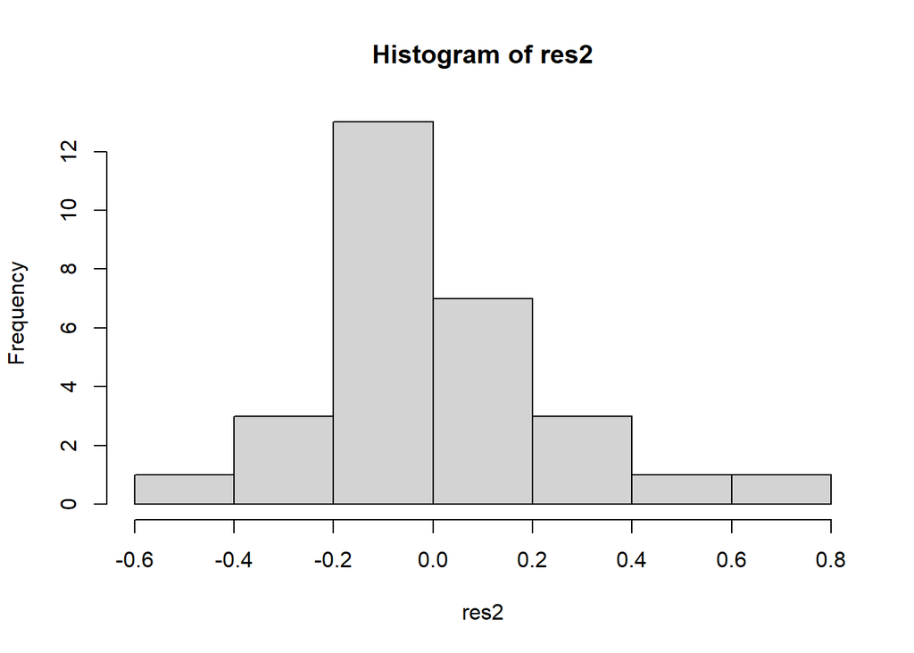

```r
hist(res2)
```

```r
#run anova of SM_log
anova(fit2)
```

```
## Analysis of Variance Table
##
## Response: SM_log
##           Df Sum Sq Mean Sq F value    Pr(>F)
## treat      2 1.2389 0.61945  9.5412 0.0007808 ***
## Residuals 26 1.6880 0.06492
## ---
## Signif. codes:  0 '***' 0.001 '**' 0.01 '*' 0.05 '.' 0.1 ' ' 1
```

```r
# Check homogeneity of variance
leveneTest(SM_log ~ treat, data=clean_data)
```

```
## Levene's Test for Homogeneity of Variance (center = median)
##       Df F value Pr(>F)
## group  2  1.2278 0.3094
##       26
```

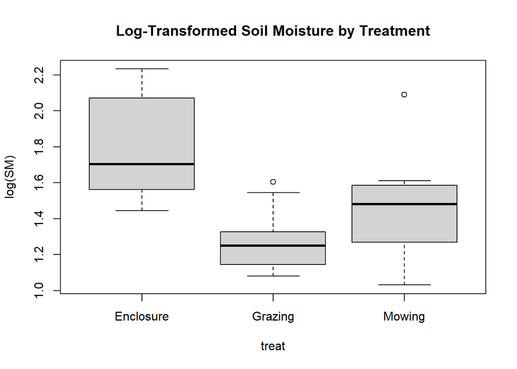

```r
# Basic boxplot
boxplot(SM_log ~ treat, data = clean_data, main = "Log-Transformed Soil Moisture by Treatment", ylab = "log(SM)")
```

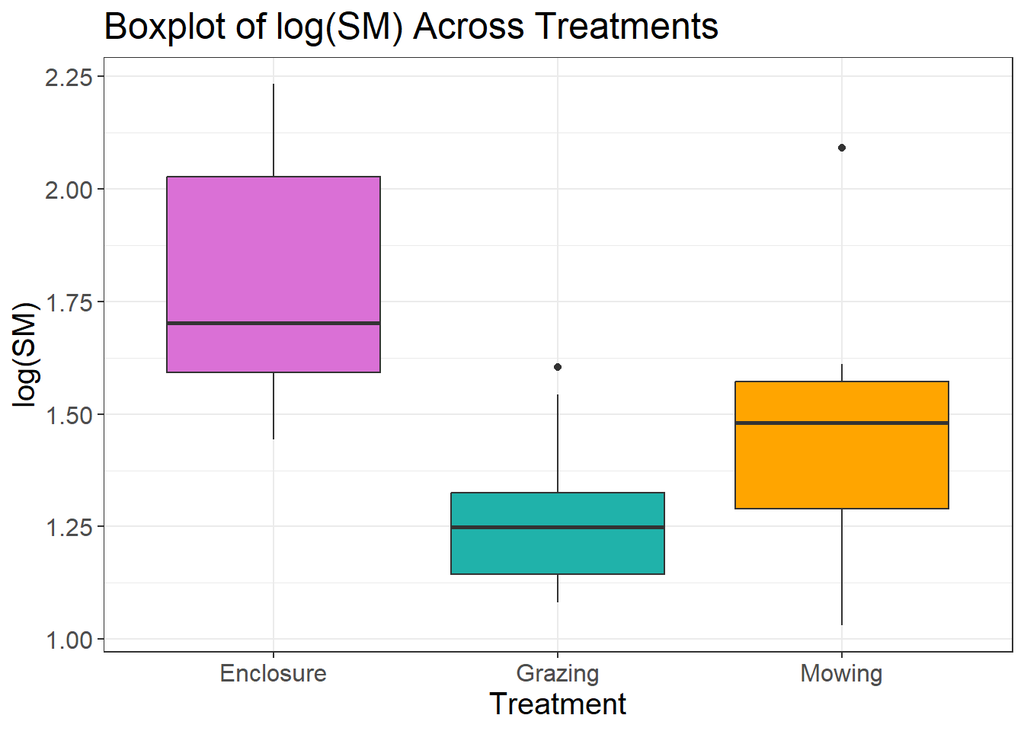

```r
# ggplot version of boxplot
ggplot(clean_data, aes(x=treat, y=SM_log, fill=treat, fill=treat))+ #base plot
  geom_boxplot(show.legend=F)+ #do a boxplot, but hide legend cause its just colors
  scale_fill_manual(values=c("orchid", "lightseagreen", "orange"))+ #set line colors
  ylab("log(SM)")+
  xlab("Treatment")+
  theme_bw()+ #cute theme+
  ggtitle("Boxplot of log(SM) Across Treatments") +
  theme(text = element_text(size=15)) # Larger font
```

#### Linear regression

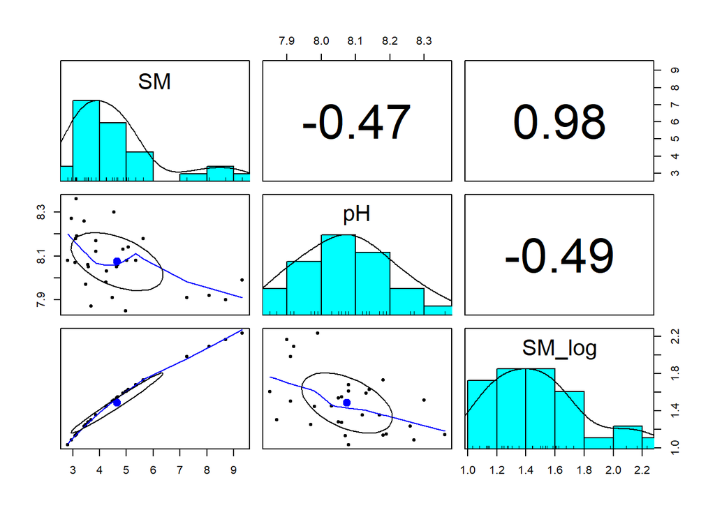

```r
# ==============================
# Part 5: Linear Regression - pH ~ SM_log
# ==============================


#prep for pairs panels: only numeric vars
numerics <- clean_data[,c("SM", "pH", "SM_log")]
pairs.panels(numerics) #include as a fig
```

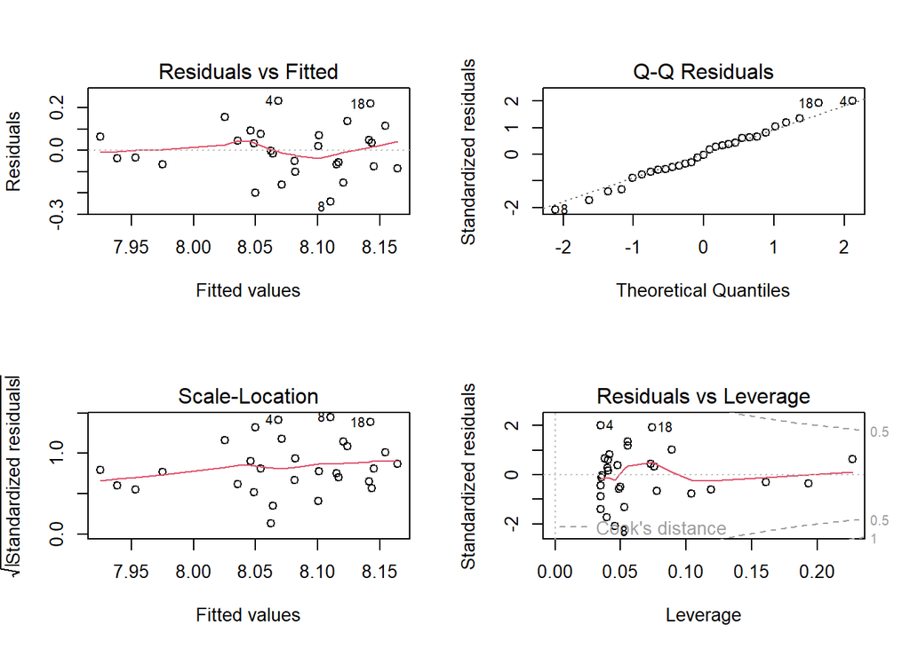

```r
fit3 <- lm(pH ~ SM_log, data = clean_data)
par(mfrow=c(2,2))
plot(fit3)
```

```r
par(mfrow=c(1,1))


summary(fit3)
```

```
##
## Call:
## lm(formula = pH ~ SM_log, data = clean_data)
##
## Residuals:
##       Min        1Q    Median        3Q       Max
## -0.240372 -0.065282 -0.002104  0.069099  0.231909
##
## Coefficients:
##             Estimate Std. Error t value Pr(>|t|)
## (Intercept)  8.36957    0.10432  80.233  < 2e-16 ***
## SM_log      -0.19914    0.06883  -2.893  0.00745 **
## ---
## Signif. codes:  0 '***' 0.001 '**' 0.01 '*' 0.05 '.' 0.1 ' ' 1
##
## Residual standard error: 0.1178 on 27 degrees of freedom
## Multiple R-squared:  0.2366, Adjusted R-squared:  0.2084
## F-statistic:  8.37 on 1 and 27 DF,  p-value: 0.007455
```

```r
# Save residuals and check normality
res3 <- fit3$residuals
shapiro.test(res3)
```

```
##
##  Shapiro-Wilk normality test
##
## data:  res3
## W = 0.98886, p-value = 0.9859
```

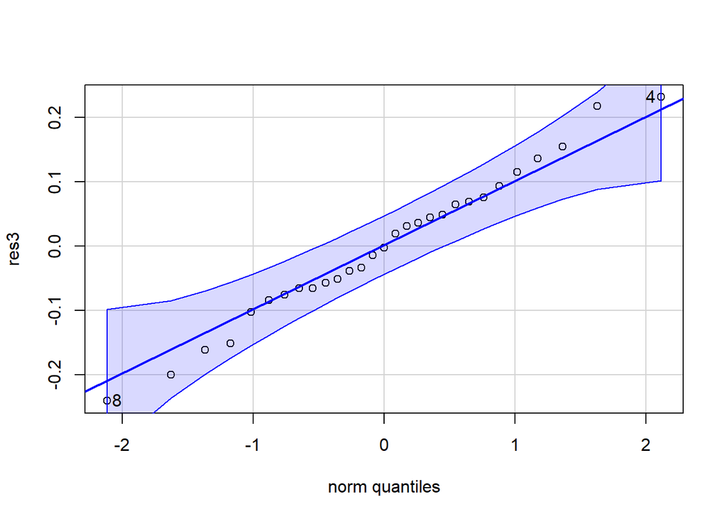

```
## [1] 8 4
```

```r
qqPlot(res3)
```

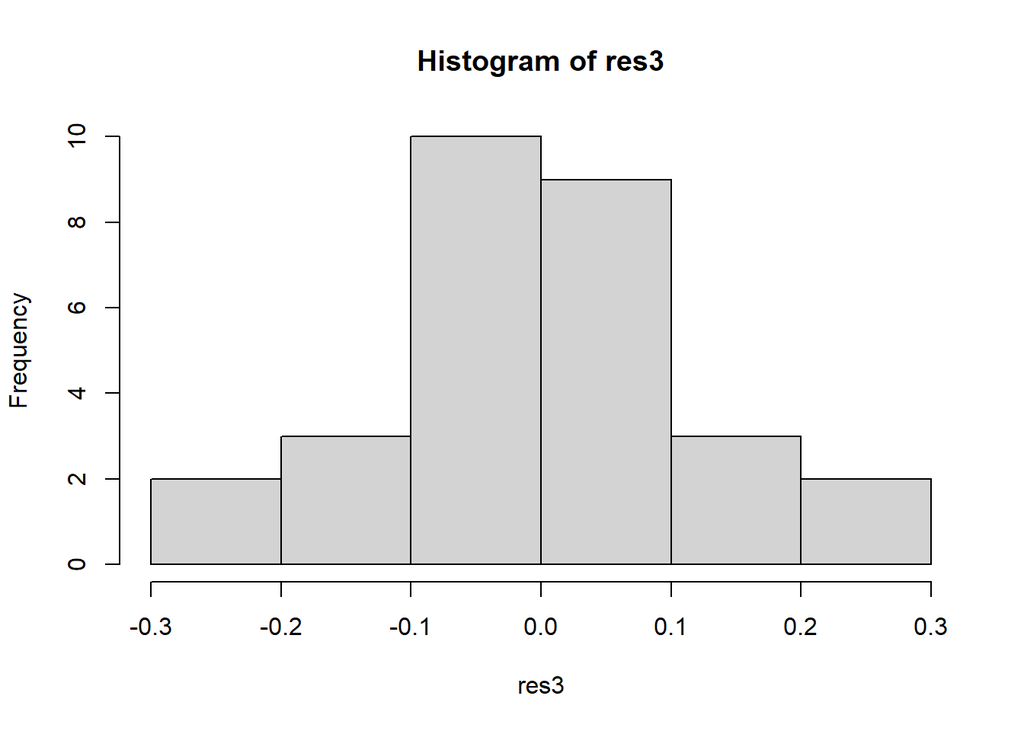

```r
hist(res3)
```

```r
ggplot(clean_data, aes(x = SM_log, y = pH)) +
  geom_point() +
  geom_smooth(method = "lm", col = "blue") +
  theme_bw() +
  labs(x = "log(Soil Moisture)", y = "pH", title = "Regression: pH ~ log(SM)")
```

[output not shown]